# Prediction of Sales Prices of Houses

### Reg. No and Name:

19BPS1012 Apurv Doddamani

19BPS1048 Anushka Pandey

19BPS1092 Mithun P

### Name of the Dataset : Housing Data of Ames, Iowa

### Loading Libraries

```r
pacman::p_load(corrplot)
pacman::p_load(ggplot2)
pacman::p_load(ggpubr)
pacman::p_load(tinytex)
pacman::p_load(tidyverse)
pacman::p_load(Metrics)
pacman::p_load(xgboost)
pacman::p_load(caret)
pacman::p_load(glmnet)
```

### Reading Data

```r
df<-read.csv("D:/COllege/5th sem/CSE3505/Project/train.csv",na.strings = "NA",header = TRUE)
head(df)
```

```
##   Id MSSubClass MSZoning LotFrontage LotArea Street Alley LotShape LandContour
## 1  1         60       RL          65    8450   Pave  <NA>      Reg         Lvl
## 2  2         20       RL          80    9600   Pave  <NA>      Reg         Lvl
## 3  3         60       RL          68   11250   Pave  <NA>      IR1         Lvl
## 4  4         70       RL          60    9550   Pave  <NA>      IR1         Lvl
## 5  5         60       RL          84   14260   Pave  <NA>      IR1         Lvl
## 6  6         50       RL          85   14115   Pave  <NA>      IR1         Lvl
##   Utilities LotConfig LandSlope Neighborhood Condition1 Condition2 BldgType
## 1    AllPub    Inside       Gtl      CollgCr       Norm       Norm     1Fam
## 2    AllPub       FR2       Gtl      Veenker      Feedr       Norm     1Fam
## 3    AllPub    Inside       Gtl      CollgCr       Norm       Norm     1Fam
## 4    AllPub    Corner       Gtl      Crawfor       Norm       Norm     1Fam
## 5    AllPub       FR2       Gtl      NoRidge       Norm       Norm     1Fam
## 6    AllPub    Inside       Gtl      Mitchel       Norm       Norm     1Fam
##   HouseStyle OverallQual OverallCond YearBuilt YearRemodAdd RoofStyle RoofMatl
```

[output cut: 69 more lines]

### Plotting Sales Price

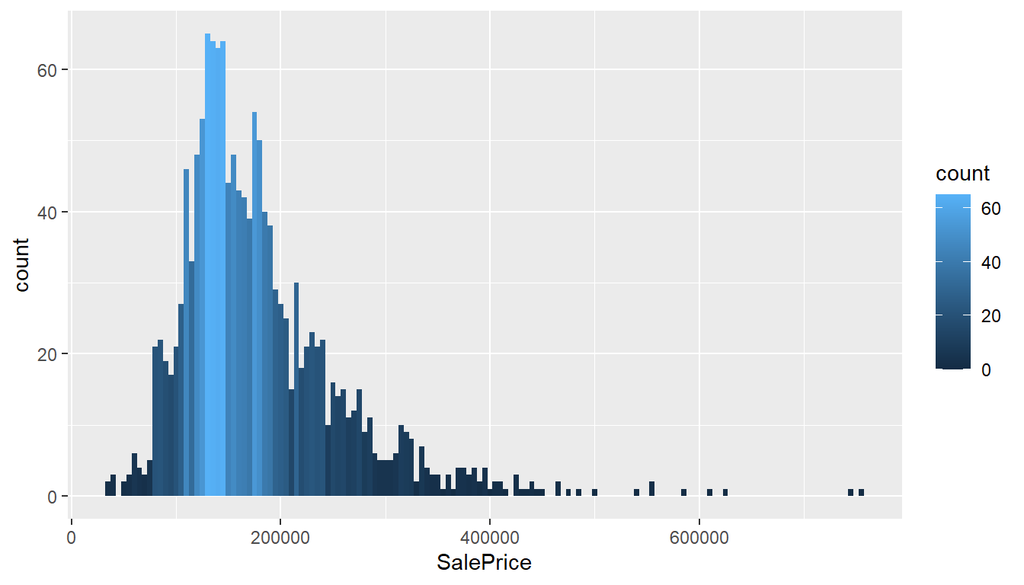

```r
options(scipen=10000)
ggplot(df,aes(SalePrice,fill = ..count..))+geom_histogram(binwidth = 5000)
```

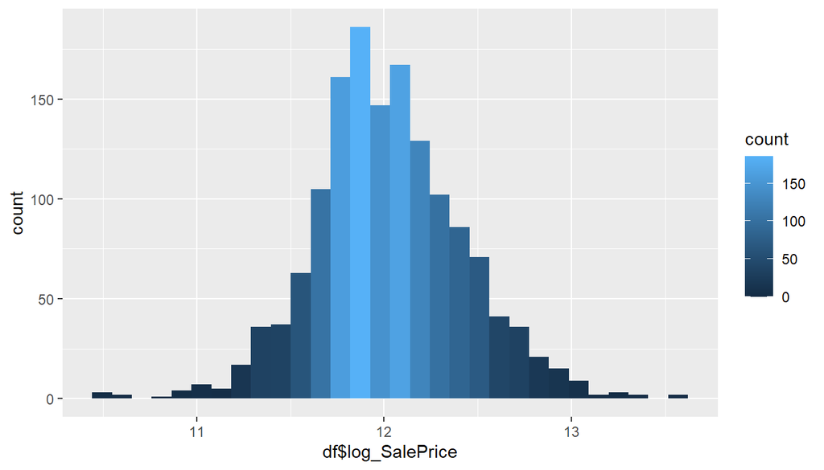

```r
df$log_SalePrice<-log(df$SalePrice)
ggplot(df,aes(df$log_SalePrice,fill = ..count..))+geom_histogram()
```

### Making GGplot and looking for linear relations

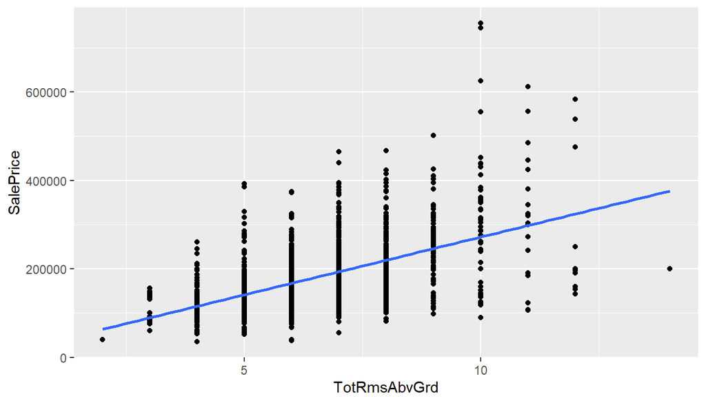

```r
ggplot(df,aes(x=TotRmsAbvGrd,y=SalePrice)) + geom_point() + geom_smooth(method ='lm', se=FALSE)
```

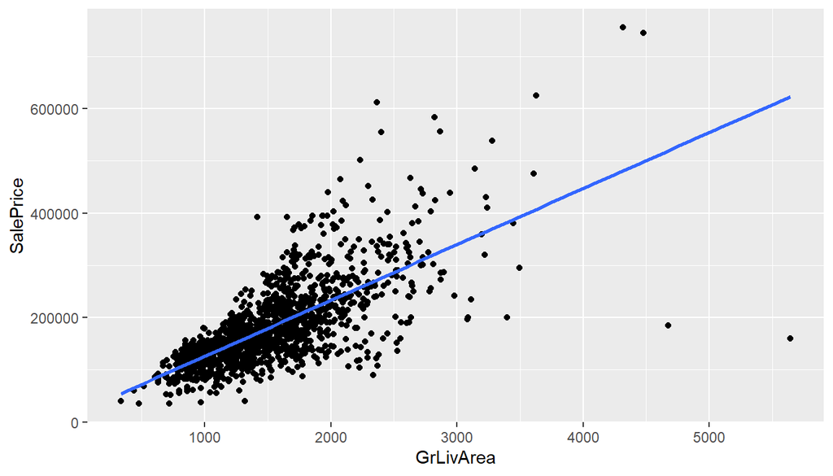

```r
ggplot(df,aes(x=GrLivArea ,y=SalePrice)) + geom_point() + geom_smooth(method ='lm', se=FALSE)
```

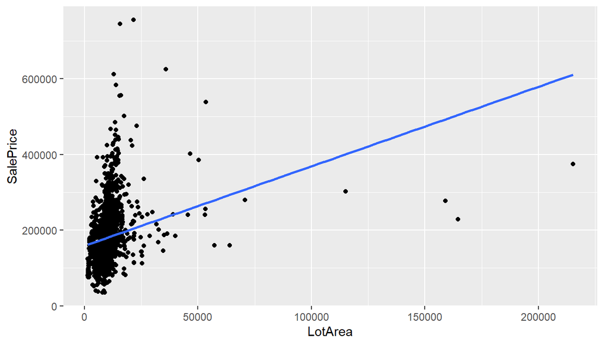

```r
ggplot(df,aes(x=LotArea ,y=SalePrice)) + geom_point() + geom_smooth(method ='lm', se=FALSE)
```

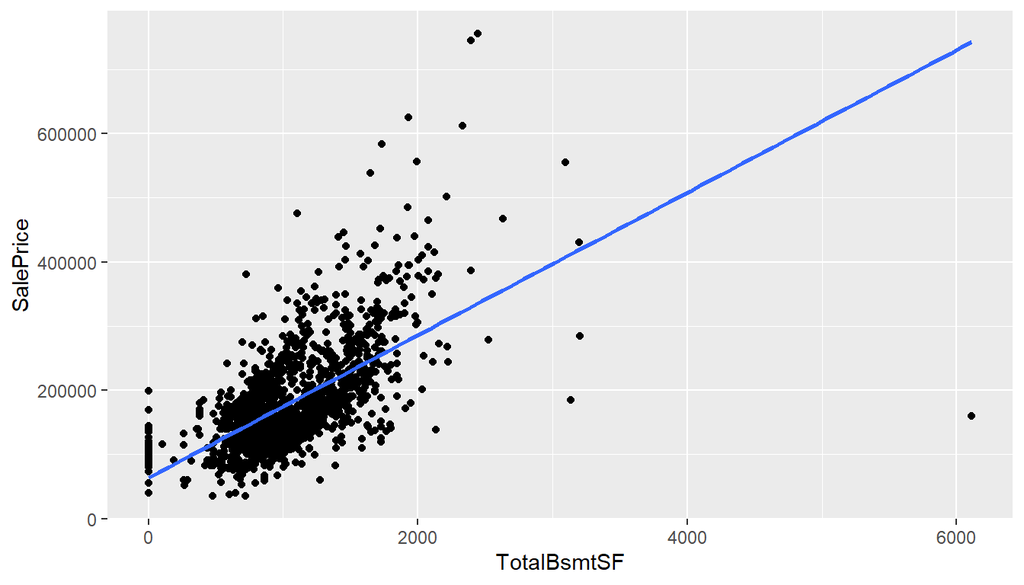

```r
ggplot(df,aes(x=TotalBsmtSF,y=SalePrice)) + geom_point() + geom_smooth(method ='lm', se=FALSE)
```

### Checking for NA values

```r
df_train_na <- as.data.frame(sapply(df, function(x) sum(is.na(x)))) %>%
  rename('na_values'='sapply(df, function(x) sum(is.na(x)))') %>% arrange(desc(na_values)) %>%
  mutate('na_percentage' = na_values/1460 *100 ) %>% filter(na_values >0)
df_train_na
```

```
##              na_values na_percentage
## PoolQC            1453   99.52054795
## MiscFeature       1406   96.30136986
## Alley             1369   93.76712329
## Fence             1179   80.75342466
## FireplaceQu        690   47.26027397
## LotFrontage        259   17.73972603
## GarageType          81    5.54794521
## GarageYrBlt         81    5.54794521
## GarageFinish        81    5.54794521
## GarageQual          81    5.54794521
## GarageCond          81    5.54794521
## BsmtExposure        38    2.60273973
## BsmtFinType2        38    2.60273973
## BsmtQual            37    2.53424658
## BsmtCond            37    2.53424658
## BsmtFinType1        37    2.53424658
## MasVnrType           8    0.54794521
## MasVnrArea           8    0.54794521
## Electrical           1    0.06849315
```

### Imputing Certain Required Features

```r
df$LotFrontage[is.na(df$LotFrontage)]<-mean(df$LotFrontage, na.rm = TRUE)
sum(is.na(df$LotFrontage))
```

```
## [1] 0
```

```r
df$MasVnrArea[is.na(df$MasVnrArea)]<-mean(df$MasVnrArea, na.rm = TRUE)
sum(is.na(df$MasVnrArea))
```

```
## [1] 0
```

### PLotting the correlation Graph

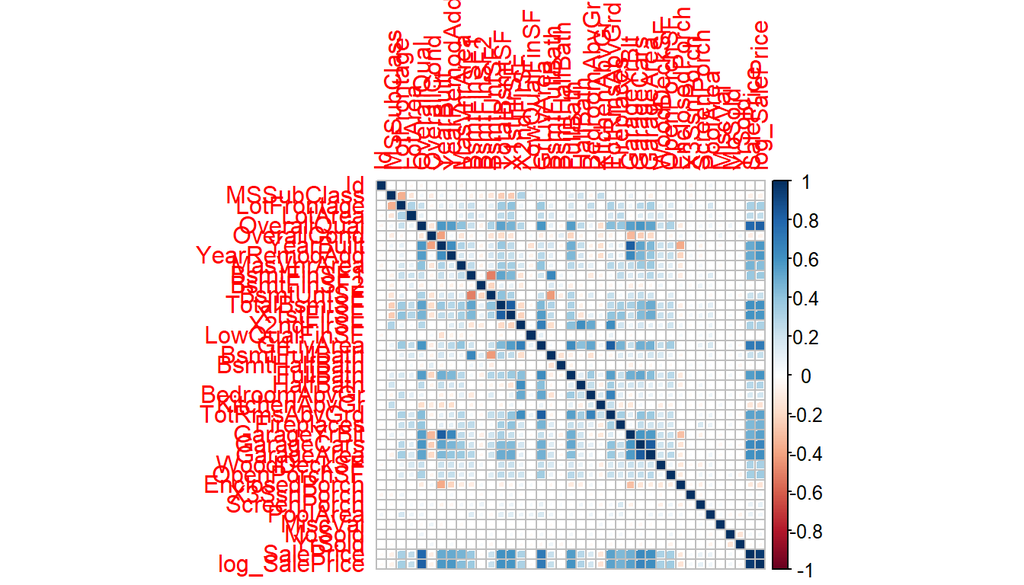

```r
house_price_num<-df[, sapply(df, is.numeric)]
Correlation<-cor(na.omit(house_price_num))
corrplot(Correlation, method = "square")
```

```r
head(Correlation)
```

```
##                      Id  MSSubClass LotFrontage      LotArea OverallQual
## Id           1.00000000  0.01952878 -0.01073538 -0.035147401 -0.04197993
## MSSubClass   0.01952878  1.00000000 -0.35773827 -0.136092300  0.05009215
## LotFrontage -0.01073538 -0.35773827  1.00000000  0.301368369  0.22641329
## LotArea     -0.03514740 -0.13609230  0.30136837  1.000000000  0.09001631
## OverallQual -0.04197993  0.05009215  0.22641329  0.090016311  1.00000000
## OverallCond  0.00714555 -0.09702697 -0.04208343 -0.002869219 -0.13623220
##              OverallCond    YearBuilt YearRemodAdd  MasVnrArea   BsmtFinSF1
## Id           0.007145550 -0.020227627  -0.02551889 -0.05390837 -0.004083389
## MSSubClass  -0.097026974  0.060041340   0.03692648  0.03374478 -0.067903826
## LotFrontage -0.042083429  0.104359069   0.08098295  0.17584966  0.220514869
## LotArea     -0.002869219 -0.005920805   0.00276392  0.09610423  0.210144876
## OverallQual -0.136232205  0.572082457   0.55777194  0.40131997  0.223689994
## OverallCond  1.000000000 -0.403601675   0.04833964 -0.13477646 -0.050817767
##               BsmtFinSF2    BsmtUnfSF TotalBsmtSF   X1stFlrSF    X2ndFlrSF
## Id          -0.007278008 -0.010067071  -0.0172779  0.01087066 -0.002178099
## MSSubClass  -0.079326243 -0.138829061  -0.2425579 -0.25398283  0.307615672
## LotFrontage  0.041868510  0.109363561   0.3592601  0.40786707  0.066673463
## LotArea      0.110010990 -0.009706822   0.2529324  0.29147788  0.046253072
## OverallQual -0.073165808  0.318551890   0.5319771  0.46742531  0.286109067
## OverallCond  0.038770312 -0.140730194  -0.1820201 -0.14717147  0.016720474
##             LowQualFinSF    GrLivArea BsmtFullBath  BsmtHalfBath     FullBath
## Id           -0.04713267  0.002616355   0.01005657 -0.0283113342  0.001604774
## MSSubClass    0.02016051  0.072672695  -0.01126396  0.0005329140  0.124322404
## LotFrontage   0.01055684  0.361329614   0.10467077 -0.0001414527  0.170442952
## LotArea       0.01017729  0.257243272   0.16104023  0.0464798493  0.117064147
## OverallQual  -0.01454954  0.589583837   0.10895521 -0.0569240294  0.556230751
## OverallCond   0.04321615 -0.092217302  -0.06177531  0.1216623009 -0.218473655
##                 HalfBath BedroomAbvGr KitchenAbvGr TotRmsAbvGrd  Fireplaces
## Id          -0.008611483   0.03742086  0.018148288   0.02463857 -0.02185482
## MSSubClass   0.197925074  -0.05843282  0.241872314   0.02181638 -0.02628352
## LotFrontage  0.039635835   0.24107806 -0.003008847   0.31595266  0.22926218
## LotArea      0.005699670   0.11974650 -0.012477459   0.18572391  0.26508305
## OverallQual  0.264944390   0.08171377 -0.173051395   0.42683435  0.38016298
## OverallCond -0.062216674   0.01498466 -0.101462646  -0.06857329 -0.02648889
##                GarageYrBlt  GarageCars  GarageArea   WoodDeckSF    OpenPorchSF
## Id           0.00007239024  0.01109930  0.01268340 -0.031904707 -0.00008230535
## MSSubClass   0.08507186951  0.01142614 -0.06648462 -0.009195121 -0.00166262558
## LotFrontage  0.06646345853  0.27002382  0.33255246  0.071679788  0.14693108577
## LotArea     -0.02494741867  0.13797759  0.16762186  0.166599815  0.08505607754
## OverallQual  0.54776584484  0.58138144  0.52810712  0.227271541  0.31904510918
## OverallCond -0.32429673253 -0.24731706 -0.19667835 -0.005638011 -0.05308958475
##             EnclosedPorch  X3SsnPorch   ScreenPorch     PoolArea       MiscVal
## Id            0.001547661 -0.04846026  0.0004602108  0.058549756 -0.0049233654
## MSSubClass   -0.022147085 -0.04395826 -0.0217320981  0.010296278 -0.0219513550
## LotFrontage   0.013014050  0.06160733  0.0324441403  0.185240098 -0.0005156793
## LotArea      -0.013426896  0.01844328  0.0386052341  0.076867872  0.0402882516
## OverallQual  -0.106609173  0.02431368  0.0505802571  0.064305238 -0.0290779787
## OverallCond   0.063195761  0.02673493  0.0575070820 -0.002273662  0.0790881765
##                   MoSold       YrSold   SalePrice log_SalePrice
## Id           0.015639469  0.008720713 -0.02763639   -0.02544323
## MSSubClass  -0.016800600 -0.023072899 -0.07770712   -0.06874842
## LotFrontage  0.017665526  0.010759876  0.32931405    0.33437705
## LotArea     -0.000557232 -0.013797348  0.25292146    0.24743056
## OverallQual  0.065337784 -0.019272613  0.78722783    0.81336518
## OverallCond -0.010564077  0.050308554 -0.09527774   -0.06465084
```

### Plotting the Graphs for Some variables

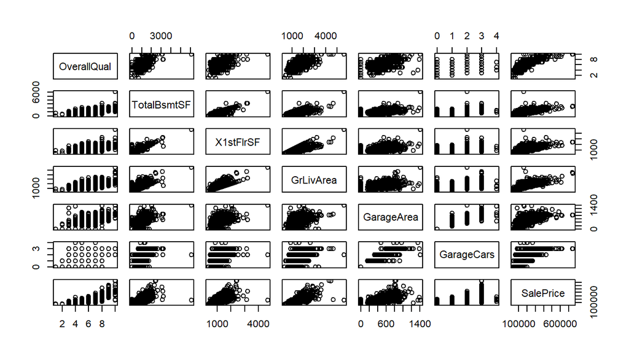

```r
predict_var<-house_price_num[c("OverallQual","TotalBsmtSF","X1stFlrSF", "GrLivArea", "GarageArea","GarageCars","SalePrice")]
plot(predict_var)
```

```r
model<-lm(SalePrice~ OverallQual + GrLivArea + GarageArea + GarageCars + TotalBsmtSF + X1stFlrSF, data = house_price_num)
summary(model)
```

```
##
## Call:
## lm(formula = SalePrice ~ OverallQual + GrLivArea + GarageArea +
##     GarageCars + TotalBsmtSF + X1stFlrSF, data = house_price_num)
##
## Residuals:
##     Min      1Q  Median      3Q     Max
## -473373  -19732   -1080   16922  288035
##
## Coefficients:
##                Estimate  Std. Error t value             Pr(>|t|)
## (Intercept) -102650.901    4903.994 -20.932 < 0.0000000000000002 ***
## OverallQual   23997.039    1083.393  22.150 < 0.0000000000000002 ***
## GrLivArea        43.123       2.679  16.095 < 0.0000000000000002 ***
## GarageArea       15.664      10.475   1.495               0.1350
## GarageCars    14515.193    3018.621   4.809         0.0000016781 ***
## TotalBsmtSF      24.391       4.318   5.649         0.0000000194 ***
## X1stFlrSF        11.186       5.032   2.223               0.0264 *
## ---
## Signif. codes:  0 '***' 0.001 '**' 0.01 '*' 0.05 '.' 0.1 ' ' 1
##
## Residual standard error: 38840 on 1453 degrees of freedom
## Multiple R-squared:  0.7619, Adjusted R-squared:  0.7609
## F-statistic:   775 on 6 and 1453 DF,  p-value: < 0.00000000000000022
```

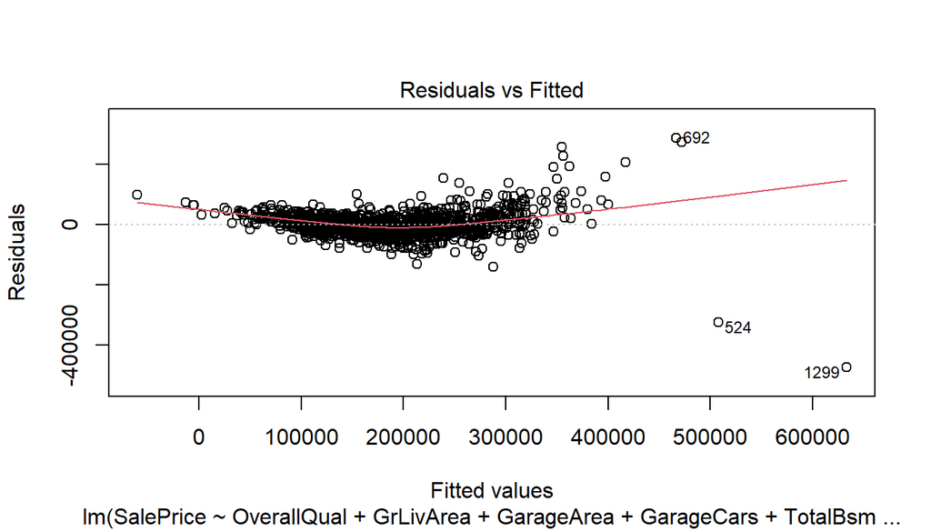

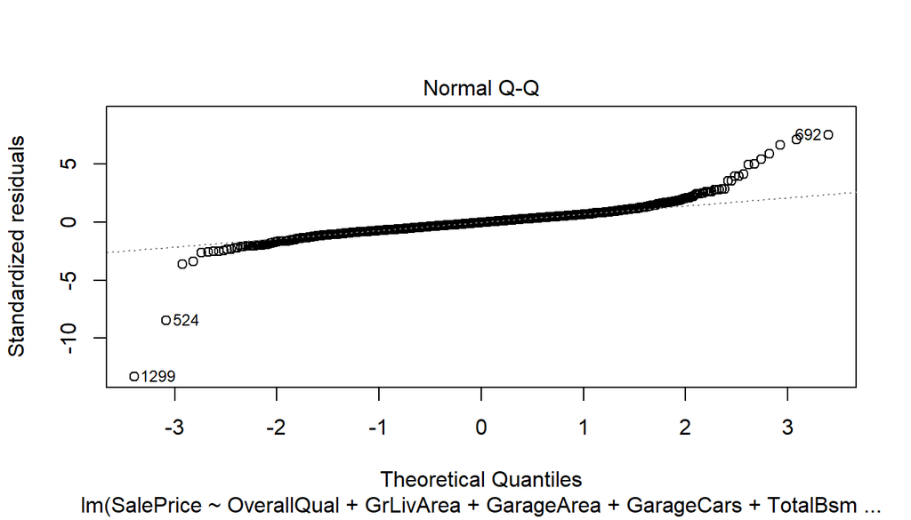

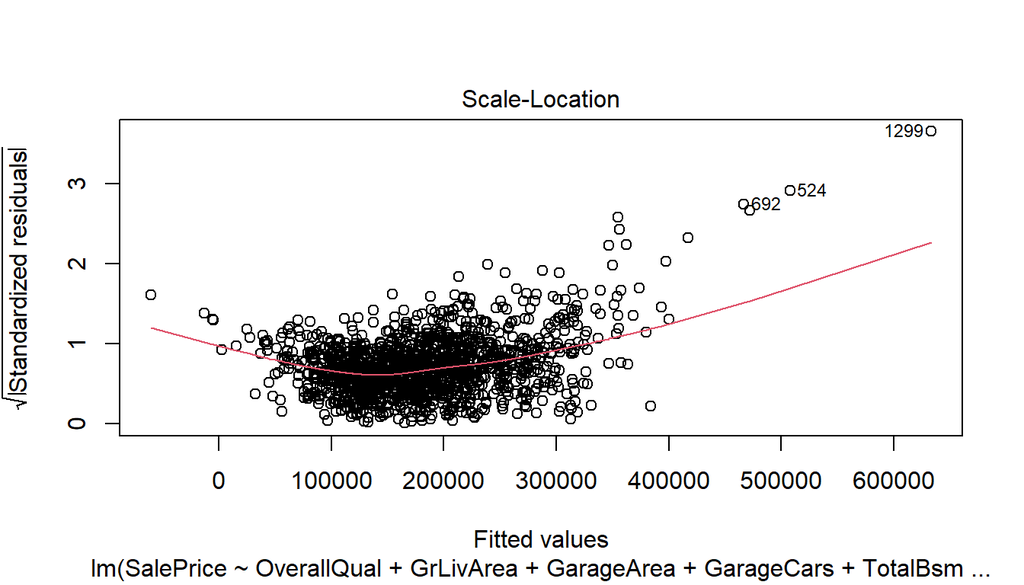

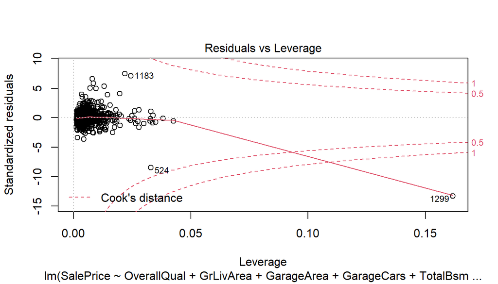

```r
plot(model)
```

#### Through summary model we can notice the significant variables and make appropriate use of them

### Evaluation Metrics

```r
k1=100*(sigma(model)/mean(house_price_num$SalePrice))
cat("Percentage Error value",k1)
```

```
## Percentage Error value 21.46949
```

```r
RMSE1= mean((house_price_num$SalePrice - predict(model))^2) %>% sqrt()
cat("\nRMSE value is",RMSE1)
```

```
##
## RMSE value is 38749.62
```

```r
model_summ <-summary(model)

RSE1 = sigma(model)
cat("\nRMSE value is",RSE1)
```

```
##
## RMSE value is 38842.85
```

```r
MSE1 = mean(model_summ$residuals^2)

cat("\nMSE value is ", MSE1)
```

```
##
## MSE value is  1501533148
```

```r
cat("\nThe RSquared values", summary(model)$r.squared)
```

```
##
## The RSquared values 0.761918
```

```r
cat("\nThe Adjusted RSquared values", summary(model)$adj.r.squared)
```

```
##
## The Adjusted RSquared values 0.7609348
```

#### We can see over here that we got pretty good R squared and Adjusted R squared Values

### Plotting Graph between actual and predicted value

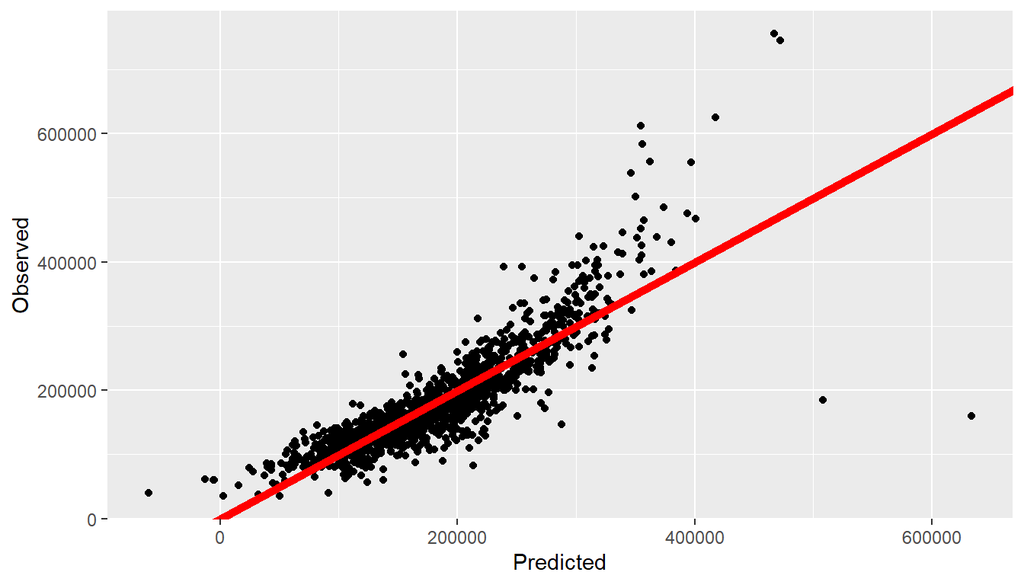

```r
data_mod <- data.frame(Predicted = predict(model),
                       Observed = house_price_num$SalePrice)

ggplot(data_mod,
       aes(x = Predicted,
           y = Observed)) +
  geom_point() +
  geom_abline(intercept = 0,
              color = "red",
              size = 2)
```

#### As we can see here the graph plotted between the acutal and predicted variables

### Multi Linear Regression Model 2

```r
model2<-lm(SalePrice~ OverallQual + GrLivArea  + GarageCars + TotalBsmtSF + X1stFlrSF + FullBath + YearBuilt  + YearRemodAdd + MasVnrArea, data = house_price_num)
summary(model2)
```

```
##
## Call:
## lm(formula = SalePrice ~ OverallQual + GrLivArea + GarageCars +
##     TotalBsmtSF + X1stFlrSF + FullBath + YearBuilt + YearRemodAdd +
##     MasVnrArea, data = house_price_num)
##
## Residuals:
##     Min      1Q  Median      3Q     Max
## -482553  -19268   -2149   16066  288942
##
## Coefficients:
##                  Estimate   Std. Error t value             Pr(>|t|)
## (Intercept)  -1175219.187   127208.181  -9.239 < 0.0000000000000002 ***
## OverallQual     18987.421     1182.648  16.055 < 0.0000000000000002 ***
## GrLivArea          48.744        3.122  15.614 < 0.0000000000000002 ***
## GarageCars      13207.761     1805.495   7.315    0.000000000000423 ***
## TotalBsmtSF        18.831        4.240   4.441    0.000009640541440 ***
## X1stFlrSF          14.666        4.874   3.009              0.00267 **
## FullBath        -6239.170     2625.867  -2.376              0.01763 *
## YearBuilt         228.872       50.313   4.549    0.000005840490093 ***
## YearRemodAdd      333.173       63.433   5.252    0.000000172553828 ***
## MasVnrArea         33.282        6.299   5.283    0.000000146252715 ***
## ---
## Signif. codes:  0 '***' 0.001 '**' 0.01 '*' 0.05 '.' 0.1 ' ' 1
##
## Residual standard error: 37580 on 1450 degrees of freedom
## Multiple R-squared:  0.7776, Adjusted R-squared:  0.7763
## F-statistic: 563.5 on 9 and 1450 DF,  p-value: < 0.00000000000000022
```

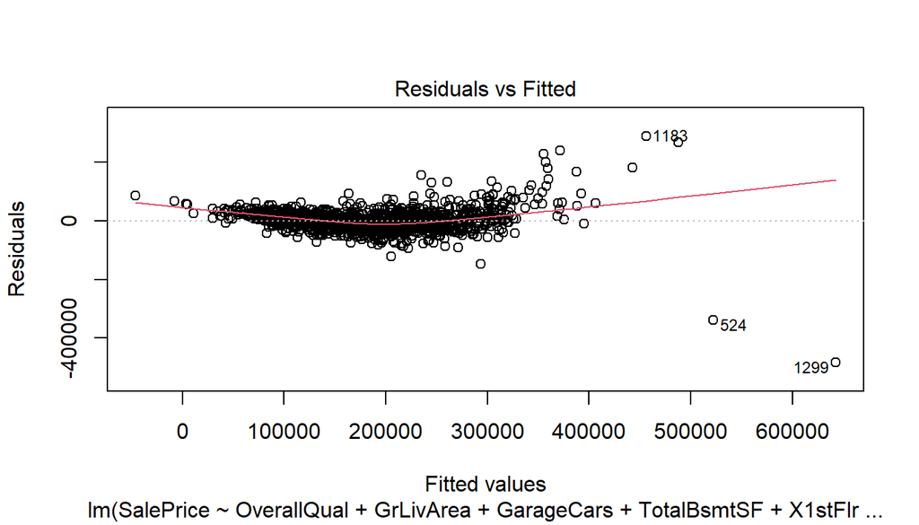

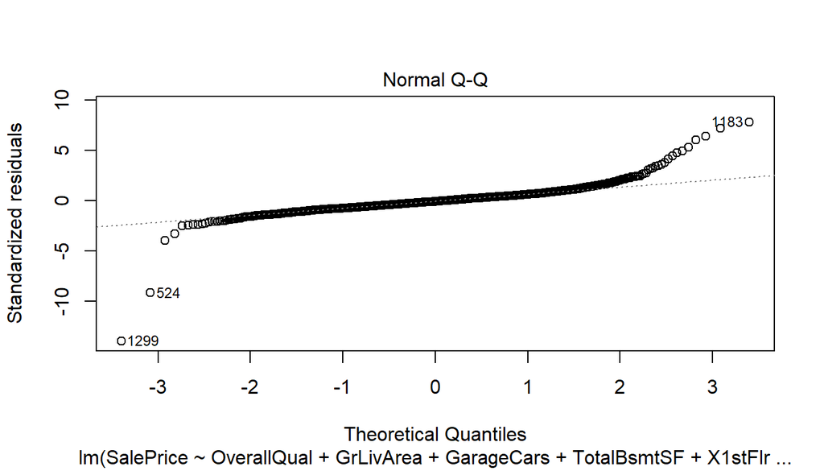

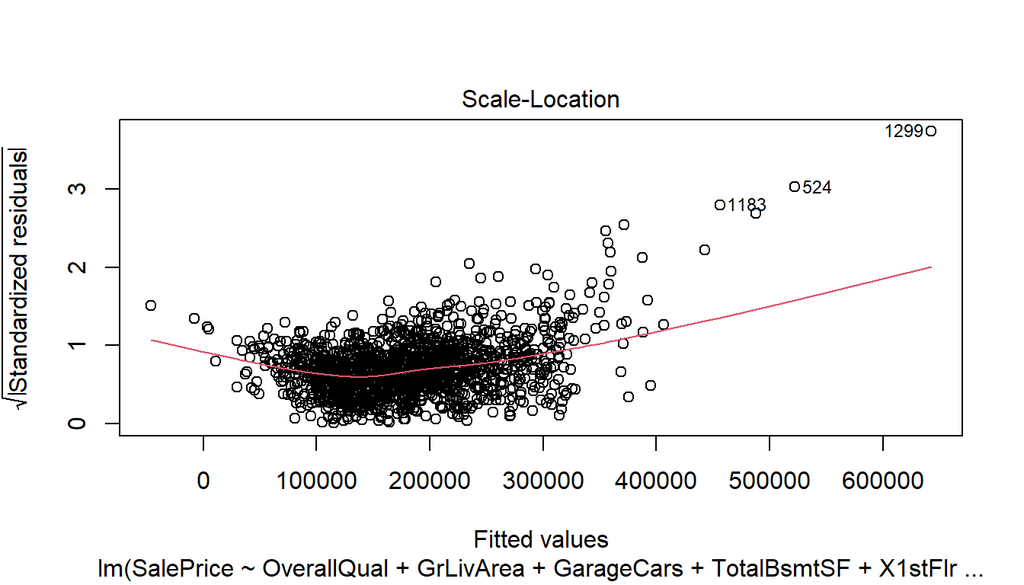

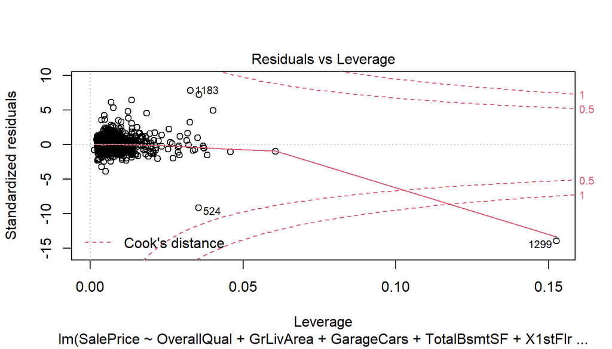

```r
plot(model2)
```

```r
k2=100*(sigma(model2)/mean(house_price_num$SalePrice))
cat("Percentage Error value",k2)
```

```
## Percentage Error value 20.76975
```

```r
RMSE2 = mean((house_price_num$SalePrice - predict(model2))^2) %>% sqrt()
cat("\nRMSE value is",RMSE2)
```

```
##
## RMSE value is 37447.97
```

```r
RSE2 = sigma(model2)
cat("\nRMSE value is",RSE2)
```

```
##
## RMSE value is 37576.88
```

```r
model_summ2 <-summary(model2)

MSE2= mean(model_summ2$residuals^2)

cat("\nMSE value is ", MSE2)
```

```
##
## MSE value is  1402350467
```

```r
cat("\nThe RSquared values", summary(model2)$r.squared)
```

```
##
## The RSquared values 0.7776443
```

```r
cat("\nThe Adjusted RSquared values", summary(model2)$adj.r.squared)
```

```
##
## The Adjusted RSquared values 0.7762641
```

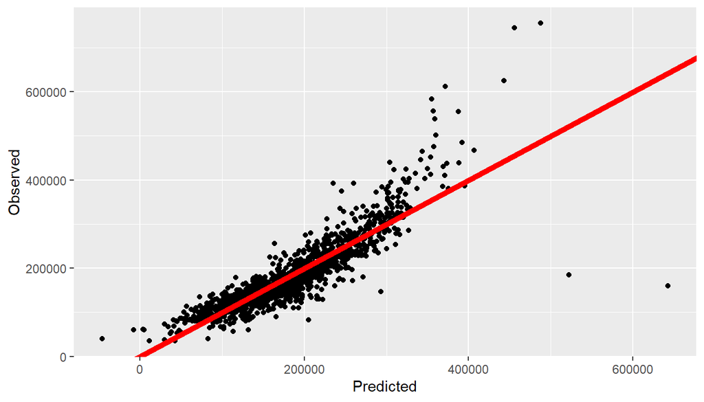

```r
data_mod <- data.frame(Predicted = predict(model2),
                       Observed = house_price_num$SalePrice)

ggplot(data_mod,
       aes(x = Predicted,
           y = Observed)) +
  geom_point() +
  geom_abline(intercept = 0,
              color = "red",
              size = 2)
```

### Multi Linear Regression Model 3

```r
model3<-lm(SalePrice~ OverallQual + GrLivArea  + GarageCars + TotalBsmtSF + X1stFlrSF + FullBath + YearBuilt  +TotRmsAbvGrd + GarageArea + YearRemodAdd + MasVnrArea, data = house_price_num)
summary(model3)
```

```
##
## Call:
## lm(formula = SalePrice ~ OverallQual + GrLivArea + GarageCars +
##     TotalBsmtSF + X1stFlrSF + FullBath + YearBuilt + TotRmsAbvGrd +
##     GarageArea + YearRemodAdd + MasVnrArea, data = house_price_num)
##
## Residuals:
##     Min      1Q  Median      3Q     Max
## -488389  -19008   -1899   15600  290196
##
## Coefficients:
##                  Estimate   Std. Error t value             Pr(>|t|)
## (Intercept)  -1175141.711   127980.386  -9.182 < 0.0000000000000002 ***
## OverallQual     19015.171     1184.924  16.048 < 0.0000000000000002 ***
## GrLivArea          48.119        4.239  11.352 < 0.0000000000000002 ***
## GarageCars      10271.172     3017.213   3.404             0.000682 ***
## TotalBsmtSF        18.447        4.266   4.324          0.000016344 ***
## X1stFlrSF          14.270        4.886   2.921             0.003546 **
## FullBath        -5957.874     2663.199  -2.237             0.025431 *
## YearBuilt         228.328       50.479   4.523          0.000006589 ***
## TotRmsAbvGrd      131.853     1109.228   0.119             0.905396
## GarageArea         12.424       10.231   1.214             0.224791
## YearRemodAdd      333.520       63.464   5.255          0.000000170 ***
## MasVnrArea         32.924        6.309   5.219          0.000000206 ***
## ---
## Signif. codes:  0 '***' 0.001 '**' 0.01 '*' 0.05 '.' 0.1 ' ' 1
##
## Residual standard error: 37580 on 1448 degrees of freedom
## Multiple R-squared:  0.7779, Adjusted R-squared:  0.7762
## F-statistic:   461 on 11 and 1448 DF,  p-value: < 0.00000000000000022
```

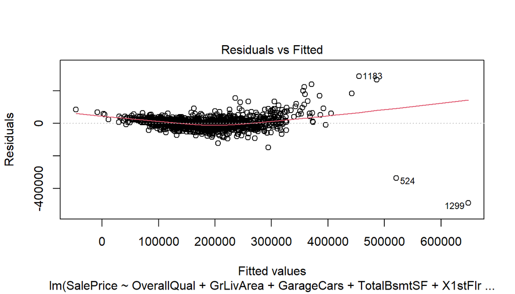

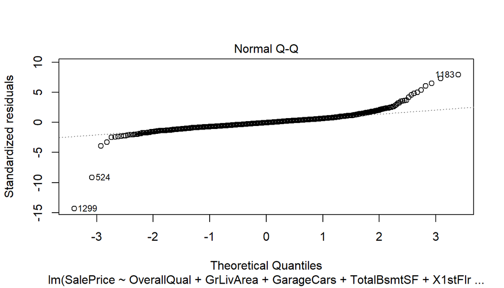

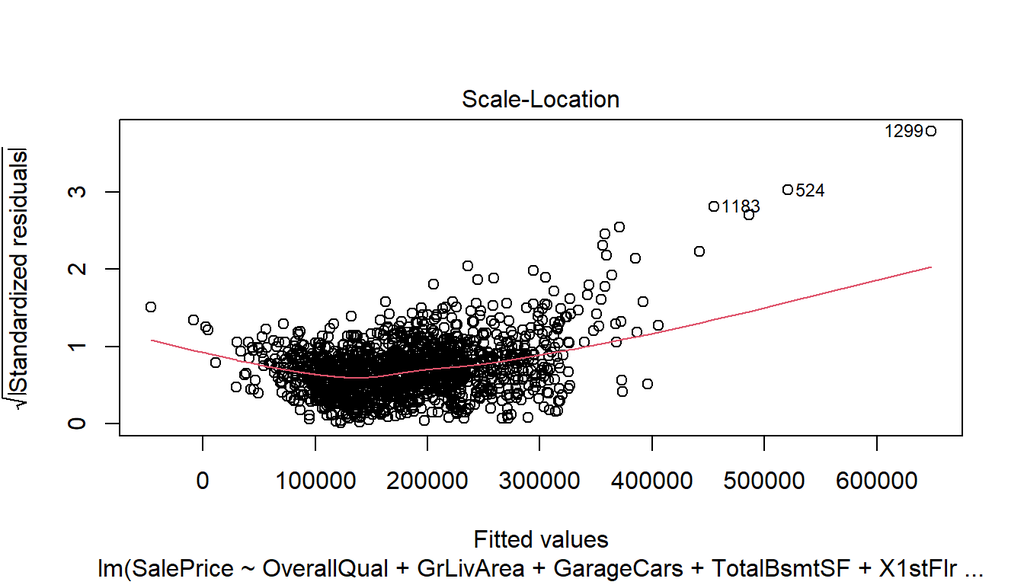

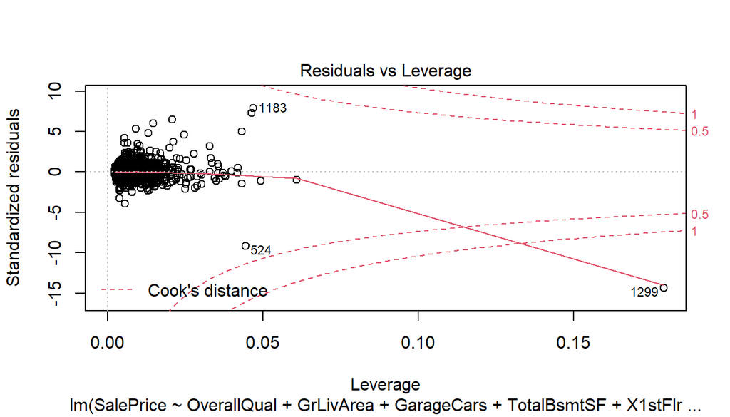

```r
plot(model3)
```

```r
k3=100*(sigma(model3)/mean(house_price_num$SalePrice))
cat("Percentage Error value",k3)
```

```
## Percentage Error value 20.7735
```

```r
RMSE3 = mean((house_price_num$SalePrice - predict(model3))^2) %>% sqrt()
cat("\nRMSE value is",RMSE3)
```

```
##
## RMSE value is 37428.9
```

```r
RSE3 = sigma(model3)
cat("\nRMSE value is",RSE3)
```

```
##
## RMSE value is 37583.67
```

```r
model_summ3 <-summary(model3)
MSE3 = mean(model_summ3$residuals^2)

cat("\nMSE value is ", MSE3)
```

```
##
## MSE value is  1400922413
```

```r
cat("\nThe RSquared values", summary(model3)$r.squared)
```

```
##
## The RSquared values 0.7778707
```

```r
cat("\nThe Adjusted RSquared values", summary(model3)$adj.r.squared)
```

```
##
## The Adjusted RSquared values 0.7761833
```

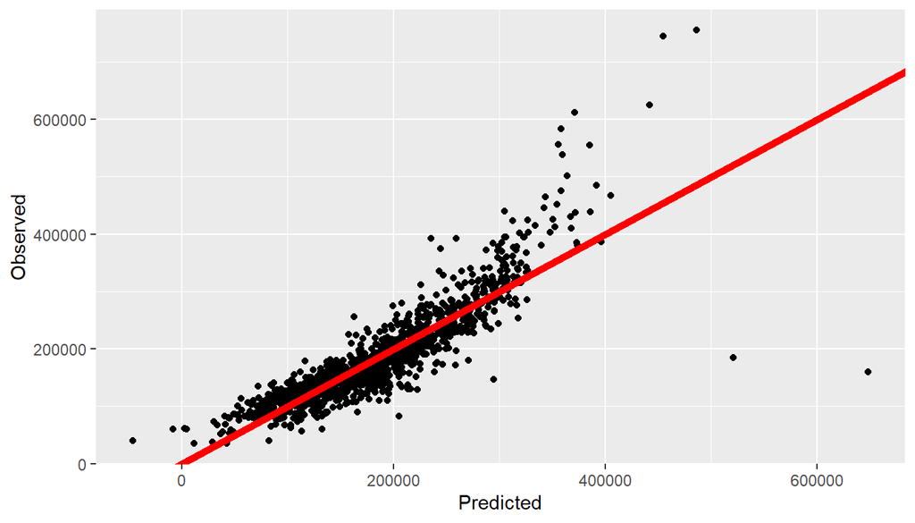

```r
data_mod <- data.frame(Predicted = predict(model3),
                       Observed = house_price_num$SalePrice)

ggplot(data_mod,
       aes(x = Predicted,
           y = Observed)) +
  geom_point() +
  geom_abline(intercept = 0,
              color = "red",
              size = 2)
```

#### Model 3 graph using some significantly related variables and we see that it can accurately predict certain values.

### Evaluation Metric for Different Multi Linear Regression

```r
Model<-c("Model1","Model2","Model3")
Error_Percentage<-c(k1,k2,k3)
RSE<-c(RSE1,RSE2,RSE3)
RMSE<-c(RMSE1,RMSE2,RMSE3)
MSE<-c(MSE1,MSE2,MSE3)
RSquared <- c(summary(model)$r.squared,summary(model2)$r.squared,summary(model3)$r.squared)
ARSquared <- c(summary(model)$adj.r.squared,summary(model2)$adj.r.squared,summary(model3)$adj.r.squared)


metricsdf<-data.frame(Model,Error_Percentage,RSE,RMSE,MSE,RSquared,ARSquared)
metricsdf
```

```
##    Model Error_Percentage      RSE     RMSE        MSE  RSquared ARSquared
## 1 Model1         21.46949 38842.85 38749.62 1501533148 0.7619180 0.7609348
## 2 Model2         20.76975 37576.88 37447.97 1402350467 0.7776443 0.7762641
## 3 Model3         20.77350 37583.67 37428.90 1400922413 0.7778707 0.7761833
```

## Polynomial Regression

```r
model4<-lm(SalePrice~ poly(OverallQual,2) + poly(GrLivArea,2)  + poly(GarageCars,1) + poly(TotalBsmtSF,2) + poly(X1stFlrSF,2) + poly(FullBath,3) + YearBuilt  +poly(TotRmsAbvGrd,4) + poly(GarageArea,4) + YearRemodAdd + poly(MasVnrArea,2), data = house_price_num)
summary(model4)
```

```
##
## Call:
## lm(formula = SalePrice ~ poly(OverallQual, 2) + poly(GrLivArea,
##     2) + poly(GarageCars, 1) + poly(TotalBsmtSF, 2) + poly(X1stFlrSF,
##     2) + poly(FullBath, 3) + YearBuilt + poly(TotRmsAbvGrd, 4) +
##     poly(GarageArea, 4) + YearRemodAdd + poly(MasVnrArea, 2),
##     data = house_price_num)
##
## Residuals:
##     Min      1Q  Median      3Q     Max
## -373868  -16066     189   14330  225021
##
## Coefficients:
##                           Estimate  Std. Error t value             Pr(>|t|)
## (Intercept)            -1179234.01   113390.56 -10.400 < 0.0000000000000002 ***
## poly(OverallQual, 2)1    979119.86    54716.09  17.895 < 0.0000000000000002 ***
## poly(OverallQual, 2)2    498349.45    38186.24  13.050 < 0.0000000000000002 ***
## poly(GrLivArea, 2)1     1106795.46    76903.51  14.392 < 0.0000000000000002 ***
## poly(GrLivArea, 2)2      -27271.24    57141.58  -0.477             0.633252
## poly(GarageCars, 1)      249540.18    80964.29   3.082             0.002095 **
## poly(TotalBsmtSF, 2)1    311605.96    72879.70   4.276        0.00002031909 ***
## poly(TotalBsmtSF, 2)2   -254548.15    71911.03  -3.540             0.000413 ***
## poly(X1stFlrSF, 2)1      172046.63    72115.39   2.386             0.017175 *
## poly(X1stFlrSF, 2)2     -197009.68    71267.76  -2.764             0.005776 **
## poly(FullBath, 3)1      -136985.24    48905.74  -2.801             0.005163 **
## poly(FullBath, 3)2       137676.28    35603.40   3.867             0.000115 ***
## poly(FullBath, 3)3       141727.50    34472.17   4.111        0.00004156270 ***
## YearBuilt                   373.43       44.01   8.485 < 0.0000000000000002 ***
## poly(TotRmsAbvGrd, 4)1   -69889.15    60983.32  -1.146             0.251971
## poly(TotRmsAbvGrd, 4)2    58926.48    39045.92   1.509             0.131478
## poly(TotRmsAbvGrd, 4)3   -48665.94    33522.11  -1.452             0.146788
## poly(TotRmsAbvGrd, 4)4   -67098.68    32871.12  -2.041             0.041407 *
## poly(GarageArea, 4)1      59418.26    75211.62   0.790             0.429650
## poly(GarageArea, 4)2      41022.11    39379.66   1.042             0.297723
## poly(GarageArea, 4)3     -93708.16    36370.49  -2.576             0.010080 *
## poly(GarageArea, 4)4    -222435.67    35520.00  -6.262        0.00000000050 ***
## YearRemodAdd                314.39       54.17   5.803        0.00000000799 ***
## poly(MasVnrArea, 2)1     115204.04    37539.52   3.069             0.002189 **
## poly(MasVnrArea, 2)2     114051.13    33571.10   3.397             0.000699 ***
## ---
## Signif. codes:  0 '***' 0.001 '**' 0.01 '*' 0.05 '.' 0.1 ' ' 1
##
## Residual standard error: 31770 on 1435 degrees of freedom
## Multiple R-squared:  0.8427, Adjusted R-squared:  0.8401
## F-statistic: 320.4 on 24 and 1435 DF,  p-value: < 0.00000000000000022
```

#### We can see over here that by changing the degree of certain varaibles we can make the model more accurate

### Evalutaion Metrics

```r
k4=100*(sigma(model4)/mean(house_price_num$SalePrice))
cat("Percentage Error value",k4)
```

```
## Percentage Error value 17.55938
```

```r
RMSE4 = mean((house_price_num$SalePrice - predict(model4))^2) %>% sqrt()
cat("\nRMSE value is",RMSE4)
```

```
##
## RMSE value is 31495.47
```

```r
RSE4 = sigma(model4)
cat("\nRMSE value is",RSE4)
```

```
##
## RMSE value is 31768.64
```

```r
model_summ4 <-summary(model4)
MSE4 = mean(model_summ4$residuals^2)

cat("\nMSE value is ", MSE4)
```

```
##
## MSE value is  991964747
```

```r
cat("\n The R Squared value is ", summary(model4)$r.squared)
```

```
##
##  The R Squared value is  0.8427148
```

```r
cat("\n The Adjusted R Squared value is ", summary(model4)$adj.r.squared)
```

```
##
##  The Adjusted R Squared value is  0.8400842
```

### Evaluation Metric for Different Regression Techniques

```r
Model<-c("Model3","Model4")
Error_Percentage<-c(k3,k4)
RSE<-c(RSE3,RSE4)
RMSE<-c(RMSE3,RMSE4)
MSE<-c(MSE3,MSE4)
RSquared <- c(summary(model3)$r.squared,summary(model4)$r.squared)
ARSquared <- c(summary(model3)$adj.r.squared,summary(model4)$adj.r.squared)
metricsdf<-data.frame(Model,Error_Percentage,RSE,RMSE,MSE,RSquared,ARSquared)
metricsdf
```

```
##    Model Error_Percentage      RSE     RMSE        MSE  RSquared ARSquared
## 1 Model3         20.77350 37583.67 37428.90 1400922413 0.7778707 0.7761833
## 2 Model4         17.55938 31768.64 31495.47  991964747 0.8427148 0.8400842
```

#### Here we have compared the metrics between best Multilinear regression and Polynomial Regression. We see a significant decrease in error metrics and improvement in accuracy values for the polynomial regression hence it is better

## ——- Ridge, Lasso, ElasticNet———-

#### These three methods are choosen so as to see if Lasso will eliminate many features which may have not had a big impact , and too see if it reduces overfitting. Ridge will reduce the impact of features that are not important in predicting our Salesprice values. Elastic Net combines feature elimination from Lasso and feature coefficient reduction from the Ridge model to improve our model’s predictions.

#### We’ve explored if the above beliefs holds true to our dataset by building 3 models in each of the methods.

```r
df<-read.csv("D:/COllege/5th sem/CSE3505/Project/train.csv",na.strings = "NA",header = TRUE)
head(df)
```

```
##   Id MSSubClass MSZoning LotFrontage LotArea Street Alley LotShape LandContour
## 1  1         60       RL          65    8450   Pave  <NA>      Reg         Lvl
## 2  2         20       RL          80    9600   Pave  <NA>      Reg         Lvl
## 3  3         60       RL          68   11250   Pave  <NA>      IR1         Lvl
## 4  4         70       RL          60    9550   Pave  <NA>      IR1         Lvl
## 5  5         60       RL          84   14260   Pave  <NA>      IR1         Lvl
## 6  6         50       RL          85   14115   Pave  <NA>      IR1         Lvl
##   Utilities LotConfig LandSlope Neighborhood Condition1 Condition2 BldgType
## 1    AllPub    Inside       Gtl      CollgCr       Norm       Norm     1Fam
## 2    AllPub       FR2       Gtl      Veenker      Feedr       Norm     1Fam
## 3    AllPub    Inside       Gtl      CollgCr       Norm       Norm     1Fam
## 4    AllPub    Corner       Gtl      Crawfor       Norm       Norm     1Fam
## 5    AllPub       FR2       Gtl      NoRidge       Norm       Norm     1Fam
## 6    AllPub    Inside       Gtl      Mitchel       Norm       Norm     1Fam
##   HouseStyle OverallQual OverallCond YearBuilt YearRemodAdd RoofStyle RoofMatl
```

[output cut: 69 more lines]

```r
df$MasVnrArea[is.na(df$MasVnrArea)]<-mean(df$MasVnrArea, na.rm = TRUE)
sum(is.na(df$MasVnrArea))
```

```
## [1] 0
```

### ———— Model - 1 ——————

```r
df1 <- data.frame(df$SalePrice , df$OverallQual , df$GrLivArea  ,df$GarageCars,df$GarageArea ,df$TotalBsmtSF,df$X1stFlrSF)

head(df1)
```

```
##   df.SalePrice df.OverallQual df.GrLivArea df.GarageCars df.GarageArea
## 1       208500              7         1710             2           548
## 2       181500              6         1262             2           460
## 3       223500              7         1786             2           608
## 4       140000              7         1717             3           642
## 5       250000              8         2198             3           836
## 6       143000              5         1362             2           480
##   df.TotalBsmtSF df.X1stFlrSF
## 1            856          856
## 2           1262         1262
## 3            920          920
## 4            756          961
## 5           1145         1145
## 6            796          796
```

### Train/Set 80/20

```r
set.seed(123)
size <- floor(0.8* nrow(df1))
```

### Training Dataset

```r
train_ind <- sample(seq_len(nrow(df1)), size = size)
train <- df1[train_ind, ]
xtrain <- train[,c(2,3,4,5,6,7)]
ytrain <- train[,1]
```

### Testing Dataset

```r
test <- df1[-train_ind, ]
xtest <- test[,c(2,3,4,5,6,7)]
ytest <- test[,1]
```

### Selecting Lambda

```r
lambda.array <- seq(from = 0.01, to = 100, by = 0.01)
```

### Performing Ridge Regression

```r
ridgefit <- glmnet(xtrain,ytrain, alpha=0, lambda = lambda.array)
summary(ridgefit)
```

```
##           Length Class     Mode
## a0        10000  -none-    numeric
## beta      60000  dgCMatrix S4
## df        10000  -none-    numeric
## dim           2  -none-    numeric
## lambda    10000  -none-    numeric
## dev.ratio 10000  -none-    numeric
## nulldev       1  -none-    numeric
## npasses       1  -none-    numeric
## jerr          1  -none-    numeric
## offset        1  -none-    logical
## call          5  -none-    call
## nobs          1  -none-    numeric
```

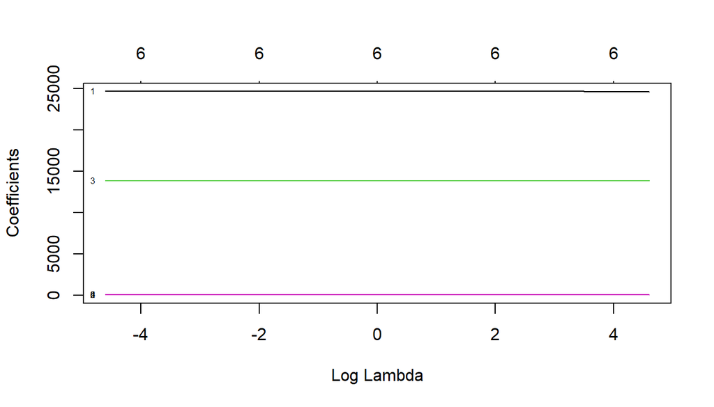

```r
plot(ridgefit, xvar= 'lambda', label = T)
```

### Predicted values:Ridge Regression:Model1

```r
y_predicted <- predict(ridgefit,s=min(lambda.array),newx = as.matrix(xtest))
```

### Co-efficients

```r
predict(ridgefit, s=min(lambda.array), newx = xtest, type = 'coefficients')
```

```
## 7 x 1 sparse Matrix of class "dgCMatrix"
##                           s1
## (Intercept)    -103101.77360
## df.OverallQual   24685.59752
## df.GrLivArea        40.59323
## df.GarageCars    13867.06634
## df.GarageArea       16.20210
## df.TotalBsmtSF      21.82002
## df.X1stFlrSF        13.73891
```

### R-Square:Ridge Regression:Model1

```r
sst <- sum((ytest - mean(ytest))^2)
sse <- sum((y_predicted - ytest)^2)

rsquare_ridge <- 1-(sse/sst)
rsquare_ridge
```

```
## [1] 0.8167762
```

```r
rsquare_ridge_1 <- rsquare_ridge
```

### Adjusted R-Square:Ridge Regression:Model1

```r
n <- nrow(as.matrix(ytest))
p <- 6

arsquare_ridge <- (1-((1-rsquare_ridge)*(n-1)/(n-p-1)))
arsquare_ridge
```

```
## [1] 0.8129188
```

### MSE:Ridge Regression:Model1

```r
MSE_ridge = (sum((y_predicted - ytest)^2) / length(y_predicted))
MSE_ridge
```

```
## [1] 1161124706
```

### RMSE:Ridge Regression:Model1

```r
rmse_ridge <- sqrt(MSE_ridge)
rmse_ridge
```

```
## [1] 34075.28
```

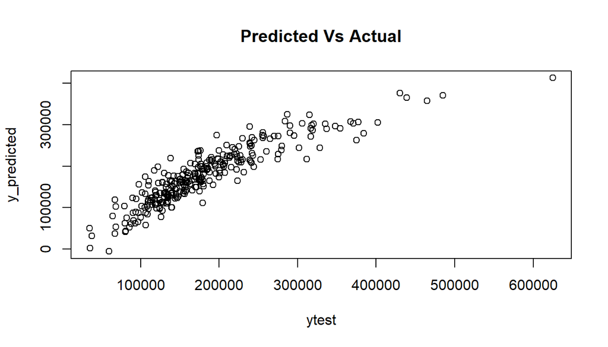

```r
plot(ytest, y_predicted, main ='Predicted Vs Actual')
```

### MAE:Ridge Regression:Model1

```r
mae(ytest,y_predicted)
```

```
## [1] 24183.42
```

#### Ridge model 1 has a:

#### MAE= 24183.42

#### MSE= 1161124706

#### RMSE = 34075.28

#### Rsquare = 0.8167762

#### Adj Rsquare = 0.8129188

## Performing LASSO Regression

```r
lassofit <- glmnet(xtrain,ytrain, alpha =1, lambda = lambda.array)
summary(lassofit)
```

```
##           Length Class     Mode
## a0        10000  -none-    numeric
## beta      60000  dgCMatrix S4
## df        10000  -none-    numeric
## dim           2  -none-    numeric
## lambda    10000  -none-    numeric
## dev.ratio 10000  -none-    numeric
## nulldev       1  -none-    numeric
## npasses       1  -none-    numeric
## jerr          1  -none-    numeric
## offset        1  -none-    logical
## call          5  -none-    call
## nobs          1  -none-    numeric
```

### Lambdas in relation to coefficients

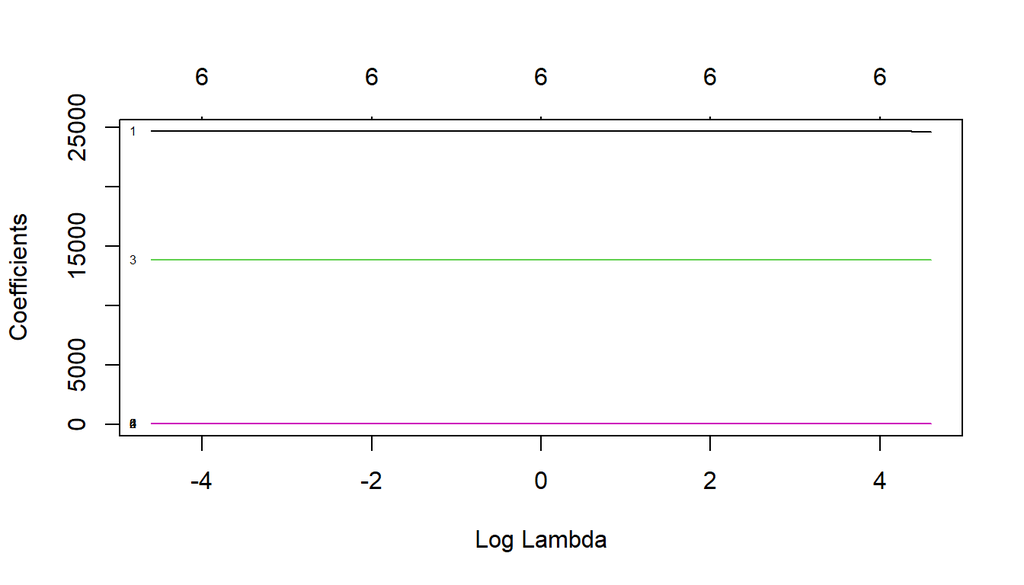

```r
plot(lassofit,xvar = 'lambda',label=T)
```

### Predicted values

```r
y_predicted_lasso <- predict(lassofit, s=min(lambda.array), newx = as.matrix(xtest))
```

### R-Square:LASSO Regression:Model1

```r
sst <- sum((ytest - mean(ytest))^2)
sse <- sum((y_predicted_lasso - ytest)^2)

rsquare_lasso <- 1-(sse/sst)
rsquare_lasso
```

```
## [1] 0.8167762
```

### Adjusted R-Square:LASSO Regression:Model1

```r
n <- nrow(as.matrix(ytest))
p <- 6

arsquare_lasso <- (1-((1-rsquare_lasso)*(n-1)/(n-p-1)))
arsquare_lasso
```

```
## [1] 0.8129188
```

### MSE:LASSO Regression:Model1

```r
MSE_lasso = (sum((y_predicted_lasso - ytest)^2) / length(y_predicted_lasso))
MSE_lasso
```

```
## [1] 1161124748
```

### RMSE:LASSO Regression:Model1

```r
rmse_lasso <- sqrt(MSE_lasso)
rmse_lasso
```

```
## [1] 34075.28
```

### MAE:LASSO Regression:Model1

```r
mae(ytest,y_predicted_lasso)
```

```
## [1] 24183.42
```

#### Lasso model 1 has a:

#### MAE= 24183.42

#### MSE= 1161124748

#### RMSE = 34075.28

#### Rsquare = 0.8167762

#### Adj Rsquare = 0.8129188

## Performing ElasticNet Regression

```r
elasticnetfit <- glmnet(xtrain,ytrain, alpha = 0.5, lambda = lambda.array)
summary(elasticnetfit)
```

```
##           Length Class     Mode
## a0        10000  -none-    numeric
## beta      60000  dgCMatrix S4
## df        10000  -none-    numeric
## dim           2  -none-    numeric
## lambda    10000  -none-    numeric
## dev.ratio 10000  -none-    numeric
## nulldev       1  -none-    numeric
## npasses       1  -none-    numeric
## jerr          1  -none-    numeric
## offset        1  -none-    logical
## call          5  -none-    call
## nobs          1  -none-    numeric
```

### Lambdas in relation to coefficients

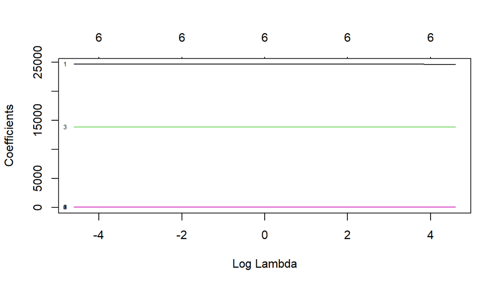

```r
plot(elasticnetfit,xvar = 'lambda',label=T)
```

### Predicted values:ELASTIC NET Regression:Model1

```r
y_predicted_elasticnet <- predict(elasticnetfit, s=min(lambda.array), newx = as.matrix(xtest))
```

### R-Square:ELASTIC NET Regression:Model1

```r
sst <- sum((ytest - mean(ytest))^2)
sse <- sum((y_predicted_elasticnet - ytest)^2)

rsquare_elasticnet <- 1-(sse/sst)
rsquare_elasticnet
```

```
## [1] 0.8167762
```

### Adjusted R-Square:ELASTIC NET Regression:Model1

```r
n <- nrow(as.matrix(ytest))
p <- 6

arsquare_elasticnet <- (1-((1-rsquare_elasticnet)*(n-1)/(n-p-1)))
arsquare_elasticnet
```

```
## [1] 0.8129188
```

### MSE:ELASTIC NET Regression:Model1

```r
MSE_elasticnet = (sum((y_predicted_elasticnet - ytest)^2) / length(y_predicted_elasticnet))
MSE_elasticnet
```

```
## [1] 1161124727
```

### RMSE:ELASTIC NET Regression:Model1

```r
rmse_elasticnet <- sqrt(MSE_elasticnet)
rmse_elasticnet
```

```
## [1] 34075.28
```

### MAE:ELASTIC NET Regression:Model1

```r
mae(ytest,y_predicted_elasticnet)
```

```
## [1] 24183.42
```

#### Elastic net model 1 has a:

#### MAE= 24183.42

#### MSE= 1161124727

#### RMSE = 34075.28

#### Rsquare = 0.8167762

#### Adj Rsquare = 0.8129188

### ———— Model - 2 ——————

```r
df1 <- data.frame(df$SalePrice , df$OverallQual , df$GrLivArea  ,df$GarageCars,df$GarageArea ,df$TotalBsmtSF,df$X1stFlrSF ,df$FullBath ,df$YearBuilt  ,df$YearRemodAdd ,df$MasVnrArea)

head(df1)
```

```
##   df.SalePrice df.OverallQual df.GrLivArea df.GarageCars df.GarageArea
## 1       208500              7         1710             2           548
## 2       181500              6         1262             2           460
## 3       223500              7         1786             2           608
## 4       140000              7         1717             3           642
## 5       250000              8         2198             3           836
## 6       143000              5         1362             2           480
##   df.TotalBsmtSF df.X1stFlrSF df.FullBath df.YearBuilt df.YearRemodAdd
## 1            856          856           2         2003            2003
## 2           1262         1262           2         1976            1976
## 3            920          920           2         2001            2002
## 4            756          961           1         1915            1970
## 5           1145         1145           2         2000            2000
## 6            796          796           1         1993            1995
##   df.MasVnrArea
## 1           196
## 2             0
## 3           162
## 4             0
## 5           350
## 6             0
```

### Train/Set 80/20

```r
set.seed(123)
size <- floor(0.8* nrow(df1))
```

### Training Dataset

```r
train_ind <- sample(seq_len(nrow(df1)), size = size)
train <- df1[train_ind, ]
xtrain <- train[,c(2,3,4,5,6,7,8,9,10,11)]
ytrain <- train[,1]
```

### Testing Dataset

```r
test <- df1[-train_ind, ]
xtest <- test[,c(2,3,4,5,6,7,8,9,10,11)]
ytest <- test[,1]
```

### Selecting Lambda

```r
lambda.array <- seq(from = 0.01, to = 100, by = 0.01)
```

### Performing Ridge Regression

```r
ridgefit <- glmnet(xtrain,ytrain, alpha=0, lambda = lambda.array)
summary(ridgefit)
```

```
##           Length Class     Mode
## a0         10000 -none-    numeric
## beta      100000 dgCMatrix S4
## df         10000 -none-    numeric
## dim            2 -none-    numeric
## lambda     10000 -none-    numeric
## dev.ratio  10000 -none-    numeric
## nulldev        1 -none-    numeric
## npasses        1 -none-    numeric
## jerr           1 -none-    numeric
## offset         1 -none-    logical
## call           5 -none-    call
## nobs           1 -none-    numeric
```

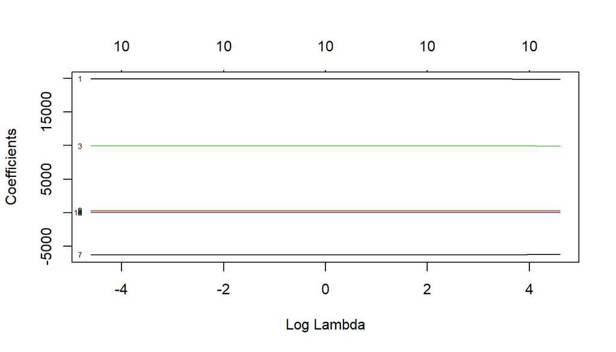

```r
plot(ridgefit, xvar= 'lambda', label = T)
```

### Predicted values:Ridge Regression:Model2

```r
y_predicted <- predict(ridgefit,s=min(lambda.array),newx = as.matrix(xtest))
```

### Co-efficients

```r
predict(ridgefit, s=min(lambda.array), newx = xtest, type = 'coefficients')
```

```
## 11 x 1 sparse Matrix of class "dgCMatrix"
##                             s1
## (Intercept)     -1195844.17856
## df.OverallQual     19908.26507
## df.GrLivArea          46.76559
## df.GarageCars       9940.33902
## df.GarageArea         13.36422
## df.TotalBsmtSF        15.32472
## df.X1stFlrSF          16.34775
## df.FullBath        -6297.30357
## df.YearBuilt         243.83855
## df.YearRemodAdd      328.01966
## df.MasVnrArea         27.12515
```

### R-Square:Ridge Regression:Model2

```r
sst <- sum((ytest - mean(ytest))^2)
sse <- sum((y_predicted - ytest)^2)

rsquare_ridge <- 1-(sse/sst)
rsquare_ridge
```

```
## [1] 0.8371325
```

```r
rsquare_ridge_1 <- rsquare_ridge
```

### Adjusted R-Square:Ridge Regression:Model2

```r
n <- nrow(as.matrix(ytest))
p <- 10

arsquare_ridge <- (1-((1-rsquare_ridge)*(n-1)/(n-p-1)))
arsquare_ridge
```

```
## [1] 0.8313365
```

### MSE:Ridge Regression:Model2

```r
MSE_ridge = (sum((y_predicted - ytest)^2) / length(y_predicted))
MSE_ridge
```

```
## [1] 1032122981
```

### RMSE:Ridge Regression:Model2

```r
rmse_ridge <- sqrt(MSE_ridge)
rmse_ridge
```

```
## [1] 32126.67
```

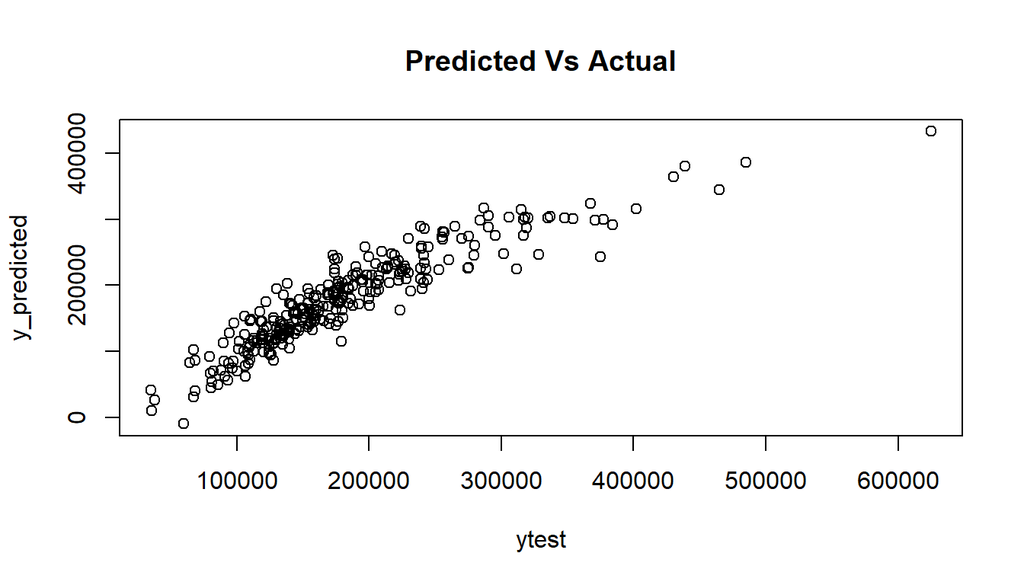

```r
plot(ytest, y_predicted, main ='Predicted Vs Actual')
```

### MAE:Ridge Regression:Model2

```r
mae(ytest,y_predicted)
```

```
## [1] 22787.67
```

## Performing LASSO Regression

```r
lassofit <- glmnet(xtrain,ytrain, alpha =1, lambda = lambda.array)
summary(lassofit)
```

```
##           Length Class     Mode
## a0         10000 -none-    numeric
## beta      100000 dgCMatrix S4
## df         10000 -none-    numeric
## dim            2 -none-    numeric
## lambda     10000 -none-    numeric
## dev.ratio  10000 -none-    numeric
## nulldev        1 -none-    numeric
## npasses        1 -none-    numeric
## jerr           1 -none-    numeric
## offset         1 -none-    logical
## call           5 -none-    call
## nobs           1 -none-    numeric
```

### Lambdas in relation to coefficients

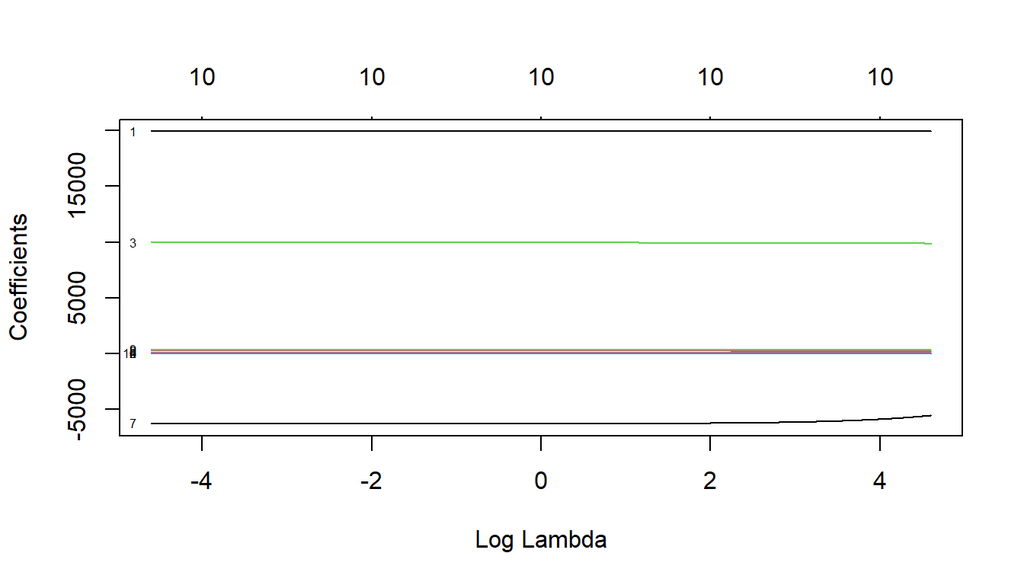

```r
plot(lassofit,xvar = 'lambda',label=T)
```

### Predicted values

```r
y_predicted_lasso <- predict(lassofit, s=min(lambda.array), newx = as.matrix(xtest))
```

### R-Square:LASSO Regression:Model2

```r
sst <- sum((ytest - mean(ytest))^2)
sse <- sum((y_predicted_lasso - ytest)^2)

rsquare_lasso <- 1-(sse/sst)
rsquare_lasso
```

```
## [1] 0.8371325
```

### Adjusted R-Square:LASSO Regression:Model2

```r
n <- nrow(as.matrix(ytest))
p <- 10

arsquare_lasso <- (1-((1-rsquare_lasso)*(n-1)/(n-p-1)))
arsquare_lasso
```

```
## [1] 0.8313365
```

### MSE:LASSO Regression:Model2

```r
MSE_lasso = (sum((y_predicted_lasso - ytest)^2) / length(y_predicted_lasso))
MSE_lasso
```

```
## [1] 1032123082
```

### RMSE:LASSO Regression:Model2

```r
rmse_lasso <- sqrt(MSE_lasso)
rmse_lasso
```

```
## [1] 32126.67
```

### MAE:LASSO Regression:Model2

```r
mae(ytest,y_predicted_lasso)
```

```
## [1] 22787.67
```

#### Lasso model 2 has a:

#### MAE= 22787.67

#### MSE= 1032123082

#### RMSE = 32126.67

#### Rsquare = 0.8371325

#### Adj Rsquare = 0.8313365

## Performing ElasticNet Regression

```r
elasticnetfit <- glmnet(xtrain,ytrain, alpha = 0.5, lambda = lambda.array)
summary(elasticnetfit)
```

```
##           Length Class     Mode
## a0         10000 -none-    numeric
## beta      100000 dgCMatrix S4
## df         10000 -none-    numeric
## dim            2 -none-    numeric
## lambda     10000 -none-    numeric
## dev.ratio  10000 -none-    numeric
## nulldev        1 -none-    numeric
## npasses        1 -none-    numeric
## jerr           1 -none-    numeric
## offset         1 -none-    logical
## call           5 -none-    call
## nobs           1 -none-    numeric
```

### Lambdas in relation to coefficients

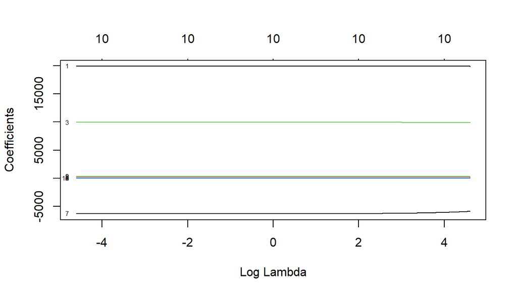

```r
plot(elasticnetfit,xvar = 'lambda',label=T)
```

### Predicted values:ELASTIC NET Regression:Model2

```r
y_predicted_elasticnet <- predict(elasticnetfit, s=min(lambda.array), newx = as.matrix(xtest))
```

### R-Square:ELASTIC NET Regression:Model2

```r
sst <- sum((ytest - mean(ytest))^2)
sse <- sum((y_predicted_elasticnet - ytest)^2)

rsquare_elasticnet <- 1-(sse/sst)
rsquare_elasticnet
```

```
## [1] 0.8371325
```

### Adjusted R-Square:ELASTIC NET Regression:Model2

```r
n <- nrow(as.matrix(ytest))
p <- 10

arsquare_elasticnet <- (1-((1-rsquare_elasticnet)*(n-1)/(n-p-1)))
arsquare_elasticnet
```

```
## [1] 0.8313365
```

### MSE:ELASTIC NET Regression:Model2

```r
MSE_elasticnet = (sum((y_predicted_elasticnet - ytest)^2) / length(y_predicted_elasticnet))
MSE_elasticnet
```

```
## [1] 1032123044
```

### RMSE:ELASTIC NET Regression:Model2

```r
rmse_elasticnet <- sqrt(MSE_elasticnet)
rmse_elasticnet
```

```
## [1] 32126.67
```

### MAE:ELASTIC NET Regression:Model2

```r
mae(ytest,y_predicted_elasticnet)
```

```
## [1] 22787.67
```

#### Elasticnet model 2 has a:

#### MAE= 22787.67

#### MSE= 1032123044

#### RMSE = 32126.67

#### Rsquare = 0.8371325

#### Adj Rsquare = 0.8313365

### ———— Model - 3 ——————

```r
df1 <- data.frame(df$SalePrice , df$OverallQual , df$GrLivArea  ,df$GarageCars,df$GarageArea ,df$TotalBsmtSF,df$X1stFlrSF ,df$FullBath ,df$YearBuilt  ,df$YearRemodAdd ,df$MasVnrArea,df$TotRmsAbvGrd)

head(df1)
```

```
##   df.SalePrice df.OverallQual df.GrLivArea df.GarageCars df.GarageArea
## 1       208500              7         1710             2           548
## 2       181500              6         1262             2           460
## 3       223500              7         1786             2           608
## 4       140000              7         1717             3           642
## 5       250000              8         2198             3           836
## 6       143000              5         1362             2           480
##   df.TotalBsmtSF df.X1stFlrSF df.FullBath df.YearBuilt df.YearRemodAdd
## 1            856          856           2         2003            2003
## 2           1262         1262           2         1976            1976
## 3            920          920           2         2001            2002
## 4            756          961           1         1915            1970
## 5           1145         1145           2         2000            2000
## 6            796          796           1         1993            1995
##   df.MasVnrArea df.TotRmsAbvGrd
## 1           196               8
## 2             0               6
## 3           162               6
## 4             0               7
## 5           350               9
## 6             0               5
```

### Train/Set 80/20

```r
set.seed(123)
size <- floor(0.8* nrow(df1))
```

### Training Dataset

```r
train_ind <- sample(seq_len(nrow(df1)), size = size)
train <- df1[train_ind, ]
xtrain <- train[,c(2,3,4,5,6,7,8,9,10,11,12)]
ytrain <- train[,1]
```

### Testing Dataset

```r
test <- df1[-train_ind, ]
xtest <- test[,c(2,3,4,5,6,7,8,9,10,11,12)]
ytest <- test[,1]
```

### Selecting Lambda

```r
lambda.array <- seq(from = 0.01, to = 100, by = 0.01)
```